# Overview

Dataset info

| Number of variables | 15 |
| --- | --- |
| Number of observations | 21265 |
| Missing cells | 94655 (29.7%) |
| Duplicate rows | 0 (0.0%) |
| Total size in memory | 2.4 MiB |
| Average record size in memory | 120.0 B |

Variables types

| Numeric | 13 |
| --- | --- |
| Categorical | 1 |
| Boolean | 0 |
| Date | 1 |
| URL | 0 |
| Text (Unique) | 0 |
| Rejected | 0 |
| Unsupported | 0 |

Warnings

| `accountgdp` has 12449 (58.5%) missing values | Missing |
| --- | --- |
| `CPI` has 2665 (12.5%) missing values | Missing |
| `fixedcap` has 11595 (54.5%) missing values | Missing |
| `foreignreserver` has 2899 (13.6%) missing values | Missing |
| `housepi` has 13004 (61.2%) missing values | Missing |
| `industrialprod` has 4771 (22.4%) missing values | Missing |
| `interbank` has 12184 (57.3%) missing values | Missing |
| `NOMexchange` has 7740 (36.4%) missing values | Missing |
| `nominalgdp` has 11330 (53.3%) missing values | Missing |
| `REexchange` has 5727 (26.9%) missing values | Missing |
| `stock` has 4304 (20.2%) missing values | Missing |
| `unemployment` has 5987 (28.2%) missing values | Missing |

# Variables

accountgdp  
Numeric

| Distinct count | 3835 |
| --- | --- |
| Unique (%) | 18.0% |
| Missing (%) | 58.5% |
| Missing (n) | 12449 |
| Infinite (%) | 0.0% |
| Infinite (n) | 0 |

| Mean | -0.3764437336 |
| --- | --- |
| Minimum | -32.02058 |
| Maximum | 43.33014 |
| Zeros (%) | 0.0% |

[figure not shown]

Toggle details

**Statistics**

Quantile statistics

| Minimum | -32.02058 |
| --- | --- |
| 5-th percentile | -7.611413 |
| Q1 | -3.558403 |
| Median | -1.139357 |
| Q3 | 2.633283 |
| 95-th percentile | 9.6246 |
| Maximum | 43.33014 |
| Range | 75.35072 |
| Interquartile range | 6.191686 |

Descriptive statistics

| Standard deviation | 5.527396997 |
| --- | --- |
| Coef of variation | -14.68319567 |
| Kurtosis | 3.138755289 |
| Mean | -0.3764437336 |
| MAD | 4.078625506 |
| Skewness | 0.2575983545 |
| Sum | -3318.727955 |
| Variance | 30.55211757 |
| Memory size | 166.2 KiB |

**Histogram**

[figure not shown]

**Histogram with fixed size bins** (bins=50)

**Common values**

| Value | Count | Frequency (%) |  |
| --- | --- | --- | --- |
| -1.745101 | 3 | < 0.1% |  |
| -2.824868 | 3 | < 0.1% |  |
| -5.820768 | 3 | < 0.1% |  |
| -2.414082 | 3 | < 0.1% |  |
| -1.603176 | 3 | < 0.1% |  |
| -2.392308 | 3 | < 0.1% |  |
| 6.227217 | 3 | < 0.1% |  |
| -0.8366022 | 3 | < 0.1% |  |
| -3.349686 | 3 | < 0.1% |  |
| -3.174215 | 3 | < 0.1% |  |
| Other values (3824) | 8786 | 41.3% |  |
| (Missing) | 12449 | 58.5% |  |

**Extreme values**

Minimum 5 values

| Value | Count | Frequency (%) |  |
| --- | --- | --- | --- |
| -32.02058 | 3 | < 0.1% |  |
| -29.8939 | 3 | < 0.1% |  |
| -27.10194 | 3 | < 0.1% |  |
| -25.26873 | 3 | < 0.1% |  |
| -25.2601 | 3 | < 0.1% |  |

Maximum 5 values

| Value | Count | Frequency (%) |  |
| --- | --- | --- | --- |
| 43.33014 | 1 | < 0.1% |  |
| 33.14931 | 1 | < 0.1% |  |
| 32.33639 | 1 | < 0.1% |  |
| 25.66556 | 1 | < 0.1% |  |
| 25.15611 | 1 | < 0.1% |  |

Country  
Categorical

| Distinct count | 45 |
| --- | --- |
| Unique (%) | 0.2% |
| Missing (%) | 0.0% |
| Missing (n) | 0 |

| Indonesia | 590 |
| --- | --- |
| Japan | 590 |
| Poland | 590 |
| Other values (42) | 19495 |

Toggle details

**Common values**

| Value | Count | Frequency (%) |  |
| --- | --- | --- | --- |
| Indonesia | 590 | 2.8% |  |
| Japan | 590 | 2.8% |  |
| Poland | 590 | 2.8% |  |
| Norway | 590 | 2.8% |  |
| Mexico | 590 | 2.8% |  |
| United States | 590 | 2.8% |  |
| South Africa | 590 | 2.8% |  |
| Canada | 590 | 2.8% |  |
| United Kingdom | 590 | 2.8% |  |
| New Zealand | 590 | 2.8% |  |
| Other values (35) | 15365 | 72.3% |  |

**Composition**

| Max length | 15 |
| --- | --- |
| Mean length | 7.908676229 |
| Min length | 5 |
| Contains chars | True |
| Contains digits | False |
| Contains spaces | True |
| Contains non-words | True |

CPI  
Numeric

| Distinct count | 12807 |
| --- | --- |
| Unique (%) | 60.2% |
| Missing (%) | 12.5% |
| Missing (n) | 2665 |
| Infinite (%) | 0.0% |
| Infinite (n) | 0 |

| Mean | 86.27937572 |
| --- | --- |
| Minimum | 0.000321 |
| Maximum | 239.6843 |
| Zeros (%) | 0.0% |

[figure not shown]

Toggle details

**Statistics**

Quantile statistics

| Minimum | 0.000321 |
| --- | --- |
| 5-th percentile | 26.554795 |
| Q1 | 72.377695 |
| Median | 89.54457 |
| Q3 | 105.329775 |
| 95-th percentile | 123.698085 |
| Maximum | 239.6843 |
| Range | 239.683979 |
| Interquartile range | 32.95208 |

Descriptive statistics

| Standard deviation | 29.03131412 |
| --- | --- |
| Coef of variation | 0.3364803452 |
| Kurtosis | 1.447695093 |
| Mean | 86.27937572 |
| MAD | 21.91390463 |
| Skewness | -0.4561961132 |
| Sum | 1604796.388 |
| Variance | 842.8171998 |
| Memory size | 166.2 KiB |

**Histogram**

[figure not shown]

**Histogram with fixed size bins** (bins=50)

**Common values**

| Value | Count | Frequency (%) |  |
| --- | --- | --- | --- |
| 100 | 96 | 0.5% |  |
| 100.2066 | 24 | 0.1% |  |
| 103.0992 | 16 | 0.1% |  |
| 99.79339 | 15 | 0.1% |  |
| 100.3099 | 15 | 0.1% |  |
| 103.5124 | 14 | 0.1% |  |
| 103.4091 | 14 | 0.1% |  |
| 107.3593 | 14 | 0.1% |  |
| 99.48347 | 13 | 0.1% |  |
| 87.77056 | 12 | 0.1% |  |
| Other values (12796) | 18367 | 86.4% |  |
| (Missing) | 2665 | 12.5% |  |

**Extreme values**

Minimum 5 values

| Value | Count | Frequency (%) |  |
| --- | --- | --- | --- |
| 0.000321 | 1 | < 0.1% |  |
| 0.000623 | 1 | < 0.1% |  |
| 0.000633 | 1 | < 0.1% |  |
| 0.000662 | 1 | < 0.1% |  |
| 0.000667 | 1 | < 0.1% |  |

Maximum 5 values

| Value | Count | Frequency (%) |  |
| --- | --- | --- | --- |
| 239.6843 | 1 | < 0.1% |  |
| 238.2638 | 1 | < 0.1% |  |
| 235.4823 | 2 | < 0.1% |  |
| 232.374 | 1 | < 0.1% |  |
| 230.4249 | 3 | < 0.1% |  |

fixedcap  
Numeric

| Distinct count | 4295 |
| --- | --- |
| Unique (%) | 20.2% |
| Missing (%) | 54.5% |
| Missing (n) | 11595 |
| Infinite (%) | 0.0% |
| Infinite (n) | 0 |

| Mean | 4327935.792 |
| --- | --- |
| Minimum | 127.701 |
| Maximum | 148351600 |
| Zeros (%) | 0.0% |

[figure not shown]

Toggle details

**Statistics**

Quantile statistics

| Minimum | 127.701 |
| --- | --- |
| 5-th percentile | 1335.518 |
| Q1 | 24799.96226 |
| Median | 78871.18768 |
| Q3 | 313383.25 |
| 95-th percentile | 32138325 |
| Maximum | 148351600 |
| Range | 148351472.3 |
| Interquartile range | 288583.2877 |

Descriptive statistics

| Standard deviation | 16600073.25 |
| --- | --- |
| Coef of variation | 3.835563662 |
| Kurtosis | 31.86672067 |
| Mean | 4327935.792 |
| MAD | 7361058.405 |
| Skewness | 5.323729083 |
| Sum | 4.185113911e+10 |
| Variance | 2.755624321e+14 |
| Memory size | 166.2 KiB |

**Histogram**

[figure not shown]

**Histogram with fixed size bins** (bins=50)

**Common values**

| Value | Count | Frequency (%) |  |
| --- | --- | --- | --- |
| 84709 | 6 | < 0.1% |  |
| 107784 | 6 | < 0.1% |  |
| 37997 | 6 | < 0.1% |  |
| 28325 | 6 | < 0.1% |  |
| 114119 | 4 | < 0.1% |  |
| 61290 | 4 | < 0.1% |  |
| 75432 | 4 | < 0.1% |  |
| 66171 | 4 | < 0.1% |  |
| 208077 | 3 | < 0.1% |  |
| 106118 | 3 | < 0.1% |  |
| Other values (4284) | 9624 | 45.3% |  |
| (Missing) | 11595 | 54.5% |  |

**Extreme values**

Minimum 5 values

| Value | Count | Frequency (%) |  |
| --- | --- | --- | --- |
| 127.701 | 1 | < 0.1% |  |
| 135.05 | 1 | < 0.1% |  |
| 147.239 | 1 | < 0.1% |  |
| 162.504 | 1 | < 0.1% |  |
| 178.1447 | 1 | < 0.1% |  |

Maximum 5 values

| Value | Count | Frequency (%) |  |
| --- | --- | --- | --- |
| 148351600 | 3 | < 0.1% |  |
| 147328700 | 3 | < 0.1% |  |
| 145387300 | 3 | < 0.1% |  |
| 144590500 | 3 | < 0.1% |  |
| 143840900 | 3 | < 0.1% |  |

foreignreserver  
Numeric

| Distinct count | 13131 |
| --- | --- |
| Unique (%) | 61.7% |
| Missing (%) | 13.6% |
| Missing (n) | 2899 |
| Infinite (%) | 0.0% |
| Infinite (n) | 0 |

| Mean | 89.19634984 |
| --- | --- |
| Minimum | 0.050252 |
| Maximum | 3191.161 |
| Zeros (%) | 0.0% |

[figure not shown]

Toggle details

**Statistics**

Quantile statistics

| Minimum | 0.050252 |
| --- | --- |
| 5-th percentile | 0.43283475 |
| Q1 | 2.39851325 |
| Median | 4.851809 |
| Q3 | 9.36419775 |
| 95-th percentile | 683.916475 |
| Maximum | 3191.161 |
| Range | 3191.110748 |
| Interquartile range | 6.9656845 |

Descriptive statistics

| Standard deviation | 321.1106977 |
| --- | --- |
| Coef of variation | 3.600043032 |
| Kurtosis | 28.6488152 |
| Mean | 89.19634984 |
| MAD | 151.7439597 |
| Skewness | 4.970557892 |
| Sum | 1638180.161 |
| Variance | 103112.0802 |
| Memory size | 166.2 KiB |

**Histogram**

[figure not shown]

**Histogram with fixed size bins** (bins=50)

**Common values**

| Value | Count | Frequency (%) |  |
| --- | --- | --- | --- |
| 11.35246 | 6 | < 0.1% |  |
| 4.419038 | 6 | < 0.1% |  |
| 0.746291 | 4 | < 0.1% |  |
| 2.149242 | 4 | < 0.1% |  |
| 1.034319 | 3 | < 0.1% |  |
| 5.215911 | 3 | < 0.1% |  |
| 15.85611 | 3 | < 0.1% |  |
| 1.468051 | 3 | < 0.1% |  |
| 5.110761 | 3 | < 0.1% |  |
| 2.289953 | 3 | < 0.1% |  |
| Other values (13120) | 18328 | 86.2% |  |
| (Missing) | 2899 | 13.6% |  |

**Extreme values**

Minimum 5 values

| Value | Count | Frequency (%) |  |
| --- | --- | --- | --- |
| 0.050252 | 1 | < 0.1% |  |
| 0.050457 | 1 | < 0.1% |  |
| 0.050607 | 1 | < 0.1% |  |
| 0.055142 | 1 | < 0.1% |  |
| 0.057348 | 1 | < 0.1% |  |

Maximum 5 values

| Value | Count | Frequency (%) |  |
| --- | --- | --- | --- |
| 3191.161 | 1 | < 0.1% |  |
| 3112.858 | 1 | < 0.1% |  |
| 3011.878 | 3 | < 0.1% |  |
| 2987.131 | 1 | < 0.1% |  |
| 2984.695 | 1 | < 0.1% |  |

housepi  
Numeric

| Distinct count | 3710 |
| --- | --- |
| Unique (%) | 17.4% |
| Missing (%) | 61.2% |
| Missing (n) | 13004 |
| Infinite (%) | 0.0% |
| Infinite (n) | 0 |

| Mean | 77.98821042 |
| --- | --- |
| Minimum | 5.787204101 |
| Maximum | 174.2924228 |
| Zeros (%) | 0.0% |

[figure not shown]

Toggle details

**Statistics**

Quantile statistics

| Minimum | 5.787204101 |
| --- | --- |
| 5-th percentile | 25.09960159 |
| Q1 | 54.36305916 |
| Median | 80.90005182 |
| Q3 | 100.594138 |
| 95-th percentile | 125.7055757 |
| Maximum | 174.2924228 |
| Range | 168.5052187 |
| Interquartile range | 46.23107884 |

Descriptive statistics

| Standard deviation | 31.76215528 |
| --- | --- |
| Coef of variation | 0.407268677 |
| Kurtosis | -0.4428894897 |
| Mean | 77.98821042 |
| MAD | 26.30074409 |
| Skewness | -0.01660216807 |
| Sum | 644260.6063 |
| Variance | 1008.834508 |
| Memory size | 166.2 KiB |

**Histogram**

[figure not shown]

**Histogram with fixed size bins** (bins=50)

**Common values**

| Value | Count | Frequency (%) |  |
| --- | --- | --- | --- |
| 86.27994228 | 6 | < 0.1% |  |
| 9.479785458 | 3 | < 0.1% |  |
| 64.86088942 | 3 | < 0.1% |  |
| 105.1004635 | 3 | < 0.1% |  |
| 86.30174888 | 3 | < 0.1% |  |
| 51.03838384 | 3 | < 0.1% |  |
| 53.283995 | 3 | < 0.1% |  |
| 85.0008658 | 3 | < 0.1% |  |
| 90.76187043 | 3 | < 0.1% |  |
| 106.5393517 | 3 | < 0.1% |  |
| Other values (3699) | 8228 | 38.7% |  |
| (Missing) | 13004 | 61.2% |  |

**Extreme values**

Minimum 5 values

| Value | Count | Frequency (%) |  |
| --- | --- | --- | --- |
| 5.787204101 | 1 | < 0.1% |  |
| 6.284261472 | 1 | < 0.1% |  |
| 6.602227466 | 1 | < 0.1% |  |
| 6.626713037 | 1 | < 0.1% |  |
| 7.398635692 | 1 | < 0.1% |  |

Maximum 5 values

| Value | Count | Frequency (%) |  |
| --- | --- | --- | --- |
| 174.2924228 | 3 | < 0.1% |  |
| 174.0389967 | 3 | < 0.1% |  |
| 173.6838478 | 3 | < 0.1% |  |
| 172.0982468 | 3 | < 0.1% |  |
| 171.8376693 | 3 | < 0.1% |  |

industrialprod  
Numeric

| Distinct count | 2276 |
| --- | --- |
| Unique (%) | 10.7% |
| Missing (%) | 22.4% |
| Missing (n) | 4771 |
| Infinite (%) | 0.0% |
| Infinite (n) | 0 |

| Mean | 2.664020965e+10 |
| --- | --- |
| Minimum | 173000000 |
| Maximum | 2.92e+11 |
| Zeros (%) | 0.0% |

[figure not shown]

Toggle details

**Statistics**

Quantile statistics

| Minimum | 173000000 |
| --- | --- |
| 5-th percentile | 508650000 |
| Q1 | 3900000000 |
| Median | 9120000000 |
| Q3 | 2.76e+10 |
| 95-th percentile | 1.39e+11 |
| Maximum | 2.92e+11 |
| Range | 2.91827e+11 |
| Interquartile range | 2.37e+10 |

Descriptive statistics

| Standard deviation | 4.966889213e+10 |
| --- | --- |
| Coef of variation | 1.86443323 |
| Kurtosis | 12.03196695 |
| Mean | 2.664020965e+10 |
| MAD | 2.810575737e+10 |
| Skewness | 3.421242407 |
| Sum | 4.39403618e+14 |
| Variance | 2.466998845e+21 |
| Memory size | 166.2 KiB |

**Histogram**

[figure not shown]

**Histogram with fixed size bins** (bins=50)

**Common values**

| Value | Count | Frequency (%) |  |
| --- | --- | --- | --- |
| 1.08e+10 | 76 | 0.4% |  |
| 1.32e+10 | 69 | 0.3% |  |
| 1.1e+10 | 65 | 0.3% |  |
| 1.37e+10 | 62 | 0.3% |  |
| 1.11e+10 | 61 | 0.3% |  |
| 1.09e+10 | 60 | 0.3% |  |
| 1.34e+10 | 59 | 0.3% |  |
| 1.36e+11 | 59 | 0.3% |  |
| 1.17e+10 | 57 | 0.3% |  |
| 1.14e+10 | 57 | 0.3% |  |
| Other values (2265) | 15869 | 74.6% |  |
| (Missing) | 4771 | 22.4% |  |

**Extreme values**

Minimum 5 values

| Value | Count | Frequency (%) |  |
| --- | --- | --- | --- |
| 173000000 | 1 | < 0.1% |  |
| 175000000 | 1 | < 0.1% |  |
| 178000000 | 3 | < 0.1% |  |
| 179000000 | 6 | < 0.1% |  |
| 182000000 | 1 | < 0.1% |  |

Maximum 5 values

| Value | Count | Frequency (%) |  |
| --- | --- | --- | --- |
| 2.92e+11 | 2 | < 0.1% |  |
| 2.9e+11 | 6 | < 0.1% |  |
| 2.89e+11 | 6 | < 0.1% |  |
| 2.88e+11 | 3 | < 0.1% |  |
| 2.87e+11 | 3 | < 0.1% |  |

interbank  
Numeric

| Distinct count | 3385 |
| --- | --- |
| Unique (%) | 15.9% |
| Missing (%) | 57.3% |
| Missing (n) | 12184 |
| Infinite (%) | 0.0% |
| Infinite (n) | 0 |

| Mean | 8.179477374 |
| --- | --- |
| Minimum | -3.65 |
| Maximum | 400.27 |
| Zeros (%) | < 0.1% |

[figure not shown]

Toggle details

**Statistics**

Quantile statistics

| Minimum | -3.65 |
| --- | --- |
| 5-th percentile | 0.001 |
| Q1 | 2 |
| Median | 5.02 |
| Q3 | 9 |
| 95-th percentile | 24 |
| Maximum | 400.27 |
| Range | 403.92 |
| Interquartile range | 7 |

Descriptive statistics

| Standard deviation | 14.86428919 |
| --- | --- |
| Coef of variation | 1.817266374 |
| Kurtosis | 141.8527692 |
| Mean | 8.179477374 |
| MAD | 6.938731438 |
| Skewness | 9.009426392 |
| Sum | 74277.83404 |
| Variance | 220.947093 |
| Memory size | 166.2 KiB |

**Histogram**

[figure not shown]

**Histogram with fixed size bins** (bins=50)

**Common values**

| Value | Count | Frequency (%) |  |
| --- | --- | --- | --- |
| 6 | 144 | 0.7% |  |
| 12 | 118 | 0.6% |  |
| 6.5 | 108 | 0.5% |  |
| 5 | 90 | 0.4% |  |
| 7.5 | 85 | 0.4% |  |
| 7 | 84 | 0.4% |  |
| 5.5 | 81 | 0.4% |  |
| 4.75 | 79 | 0.4% |  |
| 1.75 | 76 | 0.4% |  |
| 7.25 | 73 | 0.3% |  |
| Other values (3374) | 8143 | 38.3% |  |
| (Missing) | 12184 | 57.3% |  |

**Extreme values**

Minimum 5 values

| Value | Count | Frequency (%) |  |
| --- | --- | --- | --- |
| -3.65 | 1 | < 0.1% |  |
| -2 | 1 | < 0.1% |  |
| -1.75 | 2 | < 0.1% |  |
| -1.51 | 1 | < 0.1% |  |
| -1.5 | 1 | < 0.1% |  |

Maximum 5 values

| Value | Count | Frequency (%) |  |
| --- | --- | --- | --- |
| 400.27 | 1 | < 0.1% |  |
| 350.53 | 1 | < 0.1% |  |
| 262.84 | 1 | < 0.1% |  |
| 258.42 | 1 | < 0.1% |  |
| 200 | 4 | < 0.1% |  |

NOMexchange  
Numeric

| Distinct count | 9437 |
| --- | --- |
| Unique (%) | 44.4% |
| Missing (%) | 36.4% |
| Missing (n) | 7740 |
| Infinite (%) | 0.0% |
| Infinite (n) | 0 |

| Mean | 106.0516197 |
| --- | --- |
| Minimum | 33.64096 |
| Maximum | 1255.678 |
| Zeros (%) | 0.0% |

[figure not shown]

Toggle details

**Statistics**

Quantile statistics

| Minimum | 33.64096 |
| --- | --- |
| 5-th percentile | 75.18711 |
| Q1 | 92.26087 |
| Median | 98.81811 |
| Q3 | 105.7017 |
| 95-th percentile | 146.8234 |
| Maximum | 1255.678 |
| Range | 1222.03704 |
| Interquartile range | 13.44083 |

Descriptive statistics

| Standard deviation | 54.04341262 |
| --- | --- |
| Coef of variation | 0.5095953535 |
| Kurtosis | 170.2362317 |
| Mean | 106.0516197 |
| MAD | 19.16210772 |
| Skewness | 11.05479224 |
| Sum | 1434348.156 |
| Variance | 2920.690447 |
| Memory size | 166.2 KiB |

**Histogram**

[figure not shown]

**Histogram with fixed size bins** (bins=50)

**Common values**

| Value | Count | Frequency (%) |  |
| --- | --- | --- | --- |
| 101.1588 | 6 | < 0.1% |  |
| 103.3398 | 4 | < 0.1% |  |
| 102.2197 | 4 | < 0.1% |  |
| 101.0628 | 4 | < 0.1% |  |
| 98.46889 | 4 | < 0.1% |  |
| 102.6677 | 4 | < 0.1% |  |
| 102.7554 | 4 | < 0.1% |  |
| 100.5484 | 4 | < 0.1% |  |
| 101.9745 | 4 | < 0.1% |  |
| 100.24 | 4 | < 0.1% |  |
| Other values (9426) | 13483 | 63.4% |  |
| (Missing) | 7740 | 36.4% |  |

**Extreme values**

Minimum 5 values

| Value | Count | Frequency (%) |  |
| --- | --- | --- | --- |
| 33.64096 | 1 | < 0.1% |  |
| 33.81125 | 1 | < 0.1% |  |
| 34.17523 | 1 | < 0.1% |  |
| 34.19128 | 1 | < 0.1% |  |
| 34.47478 | 1 | < 0.1% |  |

Maximum 5 values

| Value | Count | Frequency (%) |  |
| --- | --- | --- | --- |
| 1255.678 | 3 | < 0.1% |  |
| 1233.399 | 1 | < 0.1% |  |
| 1186.099 | 1 | < 0.1% |  |
| 1132.636 | 3 | < 0.1% |  |
| 1079.324 | 1 | < 0.1% |  |

nominalgdp  
Numeric

| Distinct count | 4393 |
| --- | --- |
| Unique (%) | 20.7% |
| Missing (%) | 53.3% |
| Missing (n) | 11330 |
| Infinite (%) | 0.0% |
| Infinite (n) | 0 |

| Mean | 51365135.66 |
| --- | --- |
| Minimum | 135.48 |
| Maximum | 3860000000 |
| Zeros (%) | 0.0% |

[figure not shown]

Toggle details

**Statistics**

Quantile statistics

| Minimum | 135.48 |
| --- | --- |
| 5-th percentile | 5508.6 |
| Q1 | 117769.6 |
| Median | 401207 |
| Q3 | 1905120 |
| 95-th percentile | 132000000 |
| Maximum | 3860000000 |
| Range | 3859999865 |
| Interquartile range | 1787350.4 |

Descriptive statistics

| Standard deviation | 307062817.1 |
| --- | --- |
| Coef of variation | 5.978039639 |
| Kurtosis | 83.16161088 |
| Mean | 51365135.66 |
| MAD | 89176557.4 |
| Skewness | 8.773503215 |
| Sum | 5.103126228e+11 |
| Variance | 9.428757362e+16 |
| Memory size | 166.2 KiB |

**Histogram**

[figure not shown]

**Histogram with fixed size bins** (bins=50)

**Common values**

| Value | Count | Frequency (%) |  |
| --- | --- | --- | --- |
| 132000000 | 45 | 0.2% |  |
| 129000000 | 36 | 0.2% |  |
| 130000000 | 36 | 0.2% |  |
| 124000000 | 30 | 0.1% |  |
| 123000000 | 30 | 0.1% |  |
| 133000000 | 27 | 0.1% |  |
| 134000000 | 27 | 0.1% |  |
| 125000000 | 24 | 0.1% |  |
| 131000000 | 24 | 0.1% |  |
| 128000000 | 18 | 0.1% |  |
| Other values (4382) | 9638 | 45.3% |  |
| (Missing) | 11330 | 53.3% |  |

**Extreme values**

Minimum 5 values

| Value | Count | Frequency (%) |  |
| --- | --- | --- | --- |
| 135.48 | 3 | < 0.1% |  |
| 145.76 | 3 | < 0.1% |  |
| 162.22 | 3 | < 0.1% |  |
| 179.39 | 3 | < 0.1% |  |
| 208.69 | 3 | < 0.1% |  |

Maximum 5 values

| Value | Count | Frequency (%) |  |
| --- | --- | --- | --- |
| 3860000000 | 3 | < 0.1% |  |
| 3820000000 | 3 | < 0.1% |  |
| 3750000000 | 3 | < 0.1% |  |
| 3670000000 | 3 | < 0.1% |  |
| 3590000000 | 3 | < 0.1% |  |

REexchange  
Numeric

| Distinct count | 10659 |
| --- | --- |
| Unique (%) | 50.1% |
| Missing (%) | 26.9% |
| Missing (n) | 5727 |
| Infinite (%) | 0.0% |
| Infinite (n) | 0 |

| Mean | 97.21069015 |
| --- | --- |
| Minimum | 44.1767 |
| Maximum | 196.0247 |
| Zeros (%) | 0.0% |

[figure not shown]

Toggle details

**Statistics**

Quantile statistics

| Minimum | 44.1767 |
| --- | --- |
| 5-th percentile | 71.65976 |
| Q1 | 89.09884 |
| Median | 97.7898 |
| Q3 | 103.71345 |
| 95-th percentile | 123.6225 |
| Maximum | 196.0247 |
| Range | 151.848 |
| Interquartile range | 14.61461 |

Descriptive statistics

| Standard deviation | 15.75174097 |
| --- | --- |
| Coef of variation | 0.1620371272 |
| Kurtosis | 3.850428941 |
| Mean | 97.21069015 |
| MAD | 10.91830057 |
| Skewness | 0.7771032268 |
| Sum | 1510459.704 |
| Variance | 248.1173435 |
| Memory size | 166.2 KiB |

**Histogram**

[figure not shown]

**Histogram with fixed size bins** (bins=50)

**Common values**

| Value | Count | Frequency (%) |  |
| --- | --- | --- | --- |
| 122.449 | 12 | 0.1% |  |
| 92.20051 | 7 | < 0.1% |  |
| 102.8334 | 6 | < 0.1% |  |
| 99.29435 | 5 | < 0.1% |  |
| 106.7885 | 4 | < 0.1% |  |
| 100.537 | 4 | < 0.1% |  |
| 101.9718 | 4 | < 0.1% |  |
| 100.0453 | 4 | < 0.1% |  |
| 100.5807 | 4 | < 0.1% |  |
| 98.40811 | 4 | < 0.1% |  |
| Other values (10648) | 15484 | 72.8% |  |
| (Missing) | 5727 | 26.9% |  |

**Extreme values**

Minimum 5 values

| Value | Count | Frequency (%) |  |
| --- | --- | --- | --- |
| 44.1767 | 3 | < 0.1% |  |
| 45.91234 | 1 | < 0.1% |  |
| 47.48629 | 1 | < 0.1% |  |
| 47.65316 | 1 | < 0.1% |  |
| 47.79993 | 1 | < 0.1% |  |

Maximum 5 values

| Value | Count | Frequency (%) |  |
| --- | --- | --- | --- |
| 196.0247 | 1 | < 0.1% |  |
| 194.7414 | 1 | < 0.1% |  |
| 194.1551 | 1 | < 0.1% |  |
| 194.0704 | 1 | < 0.1% |  |
| 192.2822 | 1 | < 0.1% |  |

stock  
Numeric

| Distinct count | 12030 |
| --- | --- |
| Unique (%) | 56.6% |
| Missing (%) | 20.2% |
| Missing (n) | 4304 |
| Infinite (%) | 0.0% |
| Infinite (n) | 0 |

| Mean | 87.53006105 |
| --- | --- |
| Minimum | 6.193829 |
| Maximum | 1765.503 |
| Zeros (%) | 0.0% |

[figure not shown]

Toggle details

**Statistics**

Quantile statistics

| Minimum | 6.193829 |
| --- | --- |
| 5-th percentile | 19.91464 |
| Q1 | 44.09583 |
| Median | 82.15063 |
| Q3 | 115.0263 |
| 95-th percentile | 168.5544 |
| Maximum | 1765.503 |
| Range | 1759.309171 |
| Interquartile range | 70.93047 |

Descriptive statistics

| Standard deviation | 72.65815906 |
| --- | --- |
| Coef of variation | 0.8300937779 |
| Kurtosis | 156.2771886 |
| Mean | 87.53006105 |
| MAD | 41.90212516 |
| Skewness | 9.211947508 |
| Sum | 1484597.365 |
| Variance | 5279.208077 |
| Memory size | 166.2 KiB |

**Histogram**

[figure not shown]

**Histogram with fixed size bins** (bins=50)

**Common values**

| Value | Count | Frequency (%) |  |
| --- | --- | --- | --- |
| 100 | 93 | 0.4% |  |
| 102.4459 | 6 | < 0.1% |  |
| 100.6572 | 4 | < 0.1% |  |
| 26.43647 | 4 | < 0.1% |  |
| 110.4825 | 4 | < 0.1% |  |
| 111.4994 | 4 | < 0.1% |  |
| 125.0827 | 4 | < 0.1% |  |
| 105.535 | 4 | < 0.1% |  |
| 61.32552 | 3 | < 0.1% |  |
| 113.9728 | 3 | < 0.1% |  |
| Other values (12019) | 16832 | 79.2% |  |
| (Missing) | 4304 | 20.2% |  |

**Extreme values**

Minimum 5 values

| Value | Count | Frequency (%) |  |
| --- | --- | --- | --- |
| 6.193829 | 3 | < 0.1% |  |
| 6.278068 | 3 | < 0.1% |  |
| 6.305608 | 1 | < 0.1% |  |
| 6.925301 | 1 | < 0.1% |  |
| 6.984963 | 1 | < 0.1% |  |

Maximum 5 values

| Value | Count | Frequency (%) |  |
| --- | --- | --- | --- |
| 1765.503 | 1 | < 0.1% |  |
| 1764.234 | 1 | < 0.1% |  |
| 1649.751 | 1 | < 0.1% |  |
| 1561.34 | 1 | < 0.1% |  |
| 1453.535 | 1 | < 0.1% |  |

TIME  
Date

| Distinct count | 355 |
| --- | --- |
| Unique (%) | 1.7% |
| Missing (%) | 0.0% |
| Missing (n) | 0 |
| Infinite (%) | 0.0% |
| Infinite (n) | 0 |

| Minimum | 1990-02-01 00:00:00 |
| --- | --- |
| Maximum | 2019-08-01 00:00:00 |

[figure not shown]

Toggle details

[figure not shown]

unemployment  
Numeric

| Distinct count | 6554 |
| --- | --- |
| Unique (%) | 30.8% |
| Missing (%) | 28.2% |
| Missing (n) | 5987 |
| Infinite (%) | 0.0% |
| Infinite (n) | 0 |

| Mean | 8.057768915 |
| --- | --- |
| Minimum | 0.438875 |
| Maximum | 29.14951 |
| Zeros (%) | 0.0% |

[figure not shown]

Toggle details

**Statistics**

Quantile statistics

| Minimum | 0.438875 |
| --- | --- |
| 5-th percentile | 3.0036499 |
| Q1 | 5.064942 |
| Median | 7.092351 |
| Q3 | 9.6 |
| 95-th percentile | 17.0031335 |
| Maximum | 29.14951 |
| Range | 28.710635 |
| Interquartile range | 4.535058 |

Descriptive statistics

| Standard deviation | 4.663364321 |
| --- | --- |
| Coef of variation | 0.5787413824 |
| Kurtosis | 4.52022543 |
| Mean | 8.057768915 |
| MAD | 3.260093714 |
| Skewness | 1.894361704 |
| Sum | 123106.5935 |
| Variance | 21.74696679 |
| Memory size | 166.2 KiB |

**Histogram**

[figure not shown]

**Histogram with fixed size bins** (bins=50)

**Common values**

| Value | Count | Frequency (%) |  |
| --- | --- | --- | --- |
| 7.8 | 111 | 0.5% |  |
| 7.2 | 99 | 0.5% |  |
| 4.4 | 96 | 0.5% |  |
| 5.2 | 92 | 0.4% |  |
| 4.7 | 90 | 0.4% |  |
| 8.8 | 90 | 0.4% |  |
| 7 | 89 | 0.4% |  |
| 5.9 | 88 | 0.4% |  |
| 8.5 | 86 | 0.4% |  |
| 7.3 | 86 | 0.4% |  |
| Other values (6543) | 14351 | 67.5% |  |
| (Missing) | 5987 | 28.2% |  |

**Extreme values**

Minimum 5 values

| Value | Count | Frequency (%) |  |
| --- | --- | --- | --- |
| 0.438875 | 3 | < 0.1% |  |
| 0.439314 | 1 | < 0.1% |  |
| 0.44517 | 1 | < 0.1% |  |
| 0.450653 | 1 | < 0.1% |  |
| 0.4568 | 1 | < 0.1% |  |

Maximum 5 values

| Value | Count | Frequency (%) |  |
| --- | --- | --- | --- |
| 29.14951 | 1 | < 0.1% |  |
| 28.8823 | 3 | < 0.1% |  |
| 28.8759 | 1 | < 0.1% |  |
| 28.85622 | 1 | < 0.1% |  |
| 28.84112 | 1 | < 0.1% |  |

Unnamed_0  
Numeric

| Distinct count | 21265 |
| --- | --- |
| Unique (%) | 100.0% |
| Missing (%) | 0.0% |
| Missing (n) | 0 |
| Infinite (%) | 0.0% |
| Infinite (n) | 0 |

| Mean | 20472.21237 |
| --- | --- |
| Minimum | 365 |
| Maximum | 44410 |
| Zeros (%) | 0.0% |

[figure not shown]

Toggle details

**Statistics**

Quantile statistics

| Minimum | 365 |
| --- | --- |
| 5-th percentile | 1921.2 |
| Q1 | 9674 |
| Median | 18846 |
| Q3 | 31210 |
| 95-th percentile | 42623.8 |
| Maximum | 44410 |
| Range | 44045 |
| Interquartile range | 21536 |

Descriptive statistics

| Standard deviation | 12610.634 |
| --- | --- |
| Coef of variation | 0.6159878461 |
| Kurtosis | -1.080991713 |
| Mean | 20472.21237 |
| MAD | 10772.4634 |
| Skewness | 0.2817523111 |
| Sum | 435341596 |
| Variance | 159028089.9 |
| Memory size | 166.2 KiB |

**Histogram**

[figure not shown]

**Histogram with fixed size bins** (bins=50)

[figure not shown]

**Histogram with variable size bins** (bins=[ 365. 718.5 1206.5 2153.5 2241.5 ... 42948.5 43476.5 43821.5 44020.5 44410. ], ["bayesian blocks"](https://ui.adsabs.harvard.edu/abs/2013ApJ...764..167S/abstract) binning strategy used)

**Common values**

| Value | Count | Frequency (%) |  |
| --- | --- | --- | --- |
| 34815 | 1 | < 0.1% |  |
| 16957 | 1 | < 0.1% |  |
| 43584 | 1 | < 0.1% |  |
| 8769 | 1 | < 0.1% |  |
| 12867 | 1 | < 0.1% |  |
| 581 | 1 | < 0.1% |  |
| 6726 | 1 | < 0.1% |  |
| 37447 | 1 | < 0.1% |  |
| 27208 | 1 | < 0.1% |  |
| 4527 | 1 | < 0.1% |  |
| Other values (21255) | 21255 | > 99.9% |  |

**Extreme values**

Minimum 5 values

| Value | Count | Frequency (%) |  |
| --- | --- | --- | --- |
| 365 | 1 | < 0.1% |  |
| 366 | 1 | < 0.1% |  |
| 367 | 1 | < 0.1% |  |
| 368 | 1 | < 0.1% |  |
| 369 | 1 | < 0.1% |  |

Maximum 5 values

| Value | Count | Frequency (%) |  |
| --- | --- | --- | --- |
| 44410 | 1 | < 0.1% |  |
| 44409 | 1 | < 0.1% |  |
| 44408 | 1 | < 0.1% |  |
| 44407 | 1 | < 0.1% |  |
| 44406 | 1 | < 0.1% |  |

# Correlations

**Pearson's r**

[figure not shown]

**Spearman's ρ**

[figure not shown]

**Kendall's τ**

[figure not shown]

**Phik (φk)**

[figure not shown]

**Cramér's V (φc)**

[figure not shown]

**Recoded**

[figure not shown]

# Missing values

**Count**

[figure not shown]

**Matrix**

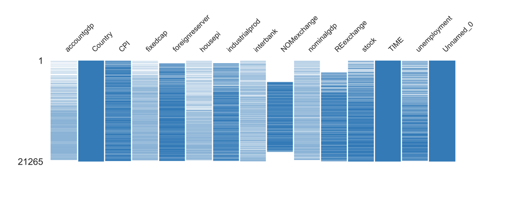

**Heatmap**

[figure not shown]

**Dendrogram**

[figure not shown]

# Sample

## First rows

|  | accountgdp | Country | CPI | fixedcap | foreignreserver | housepi | industrialprod | interbank | NOMexchange | nominalgdp | REexchange | stock | TIME | unemployment | Unnamed_0 |
| --- | --- | --- | --- | --- | --- | --- | --- | --- | --- | --- | --- | --- | --- | --- | --- |
| 0 | NaN | South Africa | 24.632640 | NaN | NaN | NaN | NaN | NaN | NaN | NaN | NaN | NaN | 1990-02-01 | NaN | 42360 |
| 1 | NaN | Belgium | 66.394660 | NaN | NaN | NaN | NaN | NaN | NaN | NaN | NaN | NaN | 1990-02-01 | 6.749932 | 2241 |
| 2 | NaN | Hungary | NaN | NaN | NaN | NaN | NaN | NaN | NaN | NaN | NaN | NaN | 1990-02-01 | NaN | 16814 |
| 3 | NaN | New Zealand | NaN | NaN | NaN | NaN | NaN | NaN | NaN | NaN | NaN | NaN | 1990-02-01 | 7.161031 | 31061 |
| 4 | NaN | Norway | 64.583330 | NaN | NaN | NaN | NaN | NaN | NaN | NaN | NaN | NaN | 1990-02-01 | 5.900000 | 30347 |
| 5 | NaN | Netherlands | 64.475100 | NaN | NaN | NaN | NaN | NaN | NaN | NaN | NaN | 32.508560 | 1990-02-01 | NaN | 29840 |
| 6 | NaN | Mexico | 10.824140 | NaN | NaN | NaN | NaN | NaN | NaN | NaN | NaN | 6.925301 | 1990-02-01 | NaN | 26630 |
| 7 | NaN | Poland | 5.324639 | NaN | NaN | NaN | NaN | NaN | NaN | NaN | NaN | NaN | 1990-02-01 | 0.700000 | 32384 |
| 8 | NaN | Latvia | NaN | NaN | NaN | NaN | NaN | NaN | NaN | NaN | NaN | NaN | 1990-02-01 | NaN | 25197 |
| 9 | NaN | Brazil | 0.000321 | NaN | NaN | NaN | NaN | NaN | NaN | NaN | NaN | NaN | 1990-02-01 | NaN | 4413 |

## Last rows

|  | accountgdp | Country | CPI | fixedcap | foreignreserver | housepi | industrialprod | interbank | NOMexchange | nominalgdp | REexchange | stock | TIME | unemployment | Unnamed_0 |
| --- | --- | --- | --- | --- | --- | --- | --- | --- | --- | --- | --- | --- | --- | --- | --- |
| 21255 | NaN | Canada | NaN | NaN | NaN | NaN | NaN | NaN | NaN | NaN | 83.49509 | 110.94070 | 2019-08-01 | NaN | 6146 |
| 21256 | NaN | Switzerland | NaN | NaN | NaN | NaN | NaN | NaN | NaN | NaN | 106.26100 | NaN | 2019-08-01 | NaN | 6967 |
| 21257 | NaN | South Africa | NaN | NaN | NaN | NaN | NaN | NaN | NaN | NaN | 77.22876 | 107.33200 | 2019-08-01 | NaN | 42949 |
| 21258 | NaN | India | NaN | NaN | NaN | NaN | NaN | NaN | NaN | NaN | 109.23340 | 142.63140 | 2019-08-01 | NaN | 18849 |
| 21259 | NaN | Lithuania | NaN | NaN | NaN | NaN | NaN | NaN | NaN | NaN | NaN | 188.39230 | 2019-08-01 | NaN | 24827 |
| 21260 | NaN | Greece | NaN | NaN | NaN | NaN | NaN | NaN | NaN | NaN | NaN | 32.47211 | 2019-08-01 | NaN | 15358 |
| 21261 | NaN | Luxembourg | NaN | NaN | NaN | NaN | NaN | NaN | NaN | NaN | NaN | 40.11712 | 2019-08-01 | NaN | 25189 |
| 21262 | NaN | Mexico | NaN | NaN | NaN | NaN | NaN | NaN | NaN | NaN | 83.90085 | 84.25110 | 2019-08-01 | NaN | 27219 |
| 21263 | NaN | Australia | NaN | NaN | NaN | NaN | NaN | NaN | NaN | NaN | 81.25784 | 105.97870 | 2019-08-01 | NaN | 1792 |
| 21264 | NaN | Spain | NaN | NaN | NaN | NaN | NaN | NaN | NaN | NaN | NaN | 57.55939 | 2019-08-01 | NaN | 12109 |